# Additional analysis

This file shows the additional analysis added to the thesis that applies the gradient boosting machines algorithm on Compustat fundamental data. This has been done on the same dataset used for the data accuracy predictions and contains observations of the included tickers in the XBRL sample and the years 2012-2020

## Data transformation

```r
CompustatML <- read.csv("CompuML2.csv")
```

```r
library(dplyr)
```

Similar to the XBRL data transformation, the Compustat data is also needed to include 3 years of consecutive data. This is classified in the following code

```r
## Obtain Ticker, Publication year and Fiscal year
New <- CompustatML[,c(3,1,2)]
New$Indicator[1] <- "Last"

## Last, Middle or First is assigned based on how the observation compares to the past and previous observation
for(i in 2:nrow(New)){
  New$Indicator[i] <- ifelse(New[i,1] != New[i-1,1]& New[i,1] == New[i+1,1] &
                       as.numeric(New[i,3]) == as.numeric(New[i+1,3])+1,"Last",ifelse(New[i,1] == New[i-1,1]&
                       New[i,1] == New[i+1,1] & as.numeric(New[i,3]) == as.numeric(New[i+1,3])+1 &
                         as.numeric(New[i,3]) != as.numeric(New[i-1,3]-1),"Last",
                         ifelse(New[i,1] == New[i-1,1]& New[i,1] == New[i+1,1] & as.numeric(New[i,3]) == as.numeric(New[i+1,3])+1 &
                         as.numeric(New[i,3]) == as.numeric(New[i-1,3])-1,"Middle", ifelse(New[i,1] == New[i-1,1] & New[i,1] != New[i+1,1] &
                         as.numeric(New[i,3]) == as.numeric(New[i-1,3])-1,"First",ifelse(New[i,1] == New[i-1,1] & New[i,1] == New[i+1,1] &
                         as.numeric(New[i,3]) == as.numeric(New[i-1,3])-1 & as.numeric(New[i,3]) != as.numeric(New[i+1,3])+1,"First","No")))))
}
CompustatML$Indicator <- New$Indicator
rm(New)
```

The observations not of use are then removed and columns with many missing values have been removed

```r
## Filter out unclassified observations and observations with many missing values
CompustatML <- CompustatML[CompustatML$Indicator != "No",]
CompustatML <- CompustatML[rowSums(is.na(CompustatML))<800,]
CompustatML <- CompustatML[,colSums(is.na(CompustatML))<15000]
CompustatML[is.na(CompustatML)] <- 0
```

The same steps applied to the XBRL data have then been applied where lagged and delta variables have been created and stored in a single machine learning output file

```r
MlDataset <- MlDataset %>% select(-Indicator)
```

[output not shown]

## Gradient Boosting machines

The same machine learning tuning steps for the gradient boositng machines model on XBRL data have then been applied to the Compustat data

```r
library(tidymodels)
library(dplyr)
library(tidymodels)
library(doParallel)
library(themis)
library(xgboost)

## Create train/test split and assign cross validation set
set.seed(12)
model_split <- initial_split(MlDataset, prop = 0.8, strata = EPS_Movement)
data_train <- training(model_split)
data_test <- testing(model_split)
set.seed(12)
cv_folds <- vfold_cv(data_train, v = 10, strata = EPS_Movement)

## Set up recipe, tune model and workflow
xgb_recipe <- recipe(EPS_Movement ~ ., data = data_train) %>% step_rm(datadate, fyear, tic, fyr, OneYearForwardEPS)

xgb_model_tune <-
  boost_tree(trees = tune(), tree_depth = tune(),
             learn_rate = tune(), stop_iter = 500) %>%
  set_mode("classification") %>%
  set_engine("xgboost")

xgb_tune_wf <- workflow() %>%
  add_recipe(xgb_recipe) %>%
  add_model(xgb_model_tune)

xgb_grid <- expand.grid(trees = 500 * 2:5,
                        learn_rate = c(0.003, 0.01, 0.03, 0.1),
                        tree_depth = 1:3)

## Define test metrics and tune model
class_metrics <- metric_set(accuracy, kap,  roc_auc)

registerDoParallel()
set.seed(12)
xgb_tune_res <- tune_grid(
  xgb_tune_wf,
  resamples = cv_folds,
  grid = xgb_grid,
  metrics = class_metrics
)
```

Based on the model tuning, the best parameters are visualised and selected

```r
xgb_tune_metrics <- xgb_tune_res %>%
  collect_metrics()

xgb_tune_metrics %>%
  filter(.metric == "accuracy") %>%
  ggplot(aes(x = trees, y = mean,
             colour = factor(tree_depth))) +
  geom_path() +
  labs(y = "Accuracy") +
  facet_wrap(~ learn_rate)
```

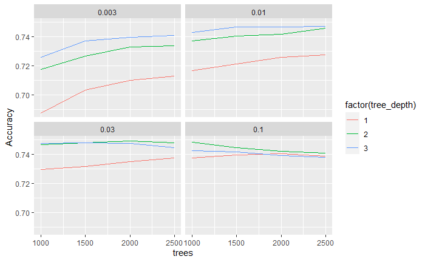

These parameters are added to the final model and the model is applied on the test set

# Results

```r
xgb_final_fit %>% collect_predictions() %>%
  conf_mat(truth = EPS_Movement, estimate = .pred_class)
```

```
          Truth
Prediction    0    1
         0 1260  596
         1  857 1405
```

[figure not shown]